# Class 3: Research Reproducibility II

Kim Johnson

February 1, 2018

## Lecture Outline

- Version control
- Git using GitBash
- Github

## Learning Objectives

1. Be able to understand what version control is and how it can potentially make your life easier
2. Be able to create a Github account
3. Understand and utilize some basic git version control *operations* and **words** (*add*, *commit*, *status*, *log*, **origin**, **master**, *push*, *pull*,*fork*)

## Version control

- How many of you have worked on assignments where multiple versions of a project file were simultaneously being altered by different people?
- Exchanging files by email?
- Working on the wrong version and then having to add your changes to a different version?

[figure not shown]

## So what is version control?

##### (with credit to https://www.visualstudio.com/learn/what-is-version-control/)

- Software for tracking changes you make to code or any files for that matter
- In the old days and perhaps now, version control involved (involves) multiple versions of the same document on your computer with version numbers or dates.

[figure not shown]

## Version control system benefits

##### (with credit to https://www.visualstudio.com/learn/what-is-version-control/)

- Manage all versions but you only see one at a time
- Every version can have a log of changes made (either specific or general)
- You can go back to any version at any time (you never lose the work)
- Facilitates collaborative coding
- You have an archive of your changes to a particular file
- Important for reproducible research!

## Version control systems

- CVS
- SVN (subversion)
- **GIT** (emerging star and harder to learn but we can do it!) **developed for plain text files but there are rich text file adaptations available
- Mecurial
- Bazaar

To read more: https://www.getfilecloud.com/blog/2015/02/top-5-open-source-version-control-tools-for-system-admins/#.WlZnw66nHAU

## Git

- Developed in 2005 by Linus Torvalds (claim to fame: Linux open source operating system creation)
- Software that takes snapshots of files in a directory at points in time and keeps a retrievable record of plain text changes

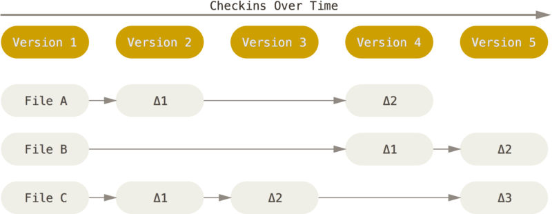

## Two main types of Git

- Command line interface (CLI, GitBash )
- Graphical user interface (GUI, Github desktop)

## What is the command line?

- User issues “commands” to a program through lines of text in what is known as a shell (e.g. Unix, *Bash* is a Unix shell)
- Has been around since the 1960s
- According to Wikipedia: “Command-line interfaces to computer operating systems are less widely used by casual computer uses, who favor graphical user interfaces or menu-driven interaction”
- Other advantages (according to Wikipedia):
  - uses fewer system resources
  - faster than GUIs with experience
  - can keep a command line history (in contrast to GUIs, which are interactive)

## Command prompts and arguments

- Character that indicates the shell’s readiness to take commands (for Unix it is $)
- Arguments follow the command prompt and tell the computer what to do

## Git-Bash is the command line shell for Git using Unix

[figure not shown]

## Steps for local version control

1. Open GitBash and set up user information using the *git config* command and then the *git config –list* command to check configuration settings

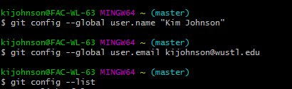

+

2. Change directory (*cd*) to a folder you want to put under version control (i.e. initialize a git repository)

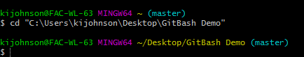

+

3. Initialize a git repository to that directory with the command *git init*

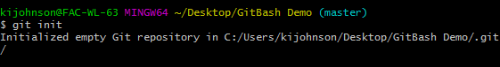

4. Create a text file using a text editor (e.g. notepad) titled *helloworld.txt* and save it to your version controlled directory

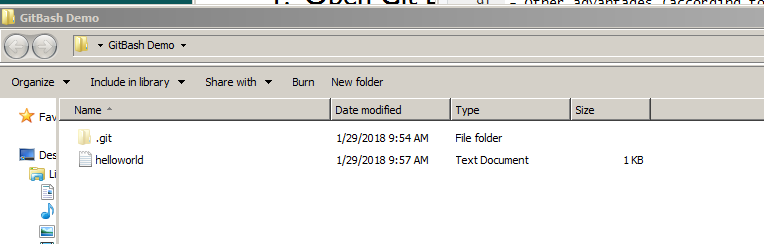

## Steps for local version control (cont.)

5. Put that file under version control using the *git add filename* command (this file is said to now be **staged** for version control)

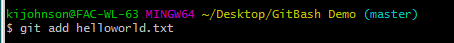

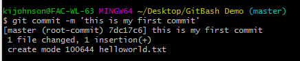

7. Make a modification to the *helloworld.txt* file, check status using the *git status* then *git add* and *git commit* commands again

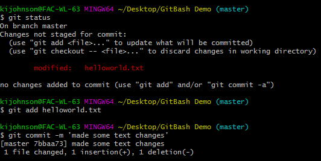

8. Check changes between the two versions using the *git log* command

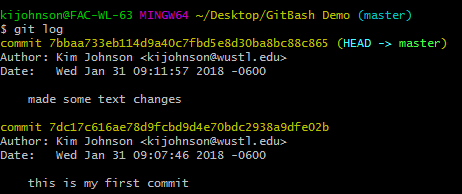

## Other useful git commands/further explanation

- *git status*: allows you to check what state your files are in

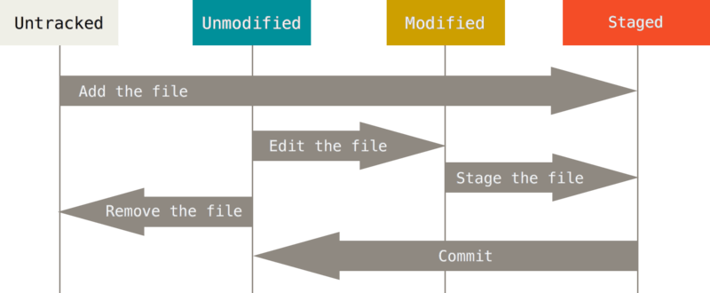

- *git log - -pretty=format:“%h %s” - -graph*: To get a graph of commits with abbreviated hash numbers for each commit (for output options, see: https://git-scm.com/book/en/v2/Git-Basics-Viewing-the-Commit-History)
- *git reset - -hard commit hash*: To reset a file version to an earlier commit. Note for commit hash, you need to insert the long or abbreviated alphanumeric number for the commit

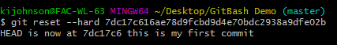

## Steps for using Github for remote version control

### Github is a cloud repository that you can use for remote version control

1. Go to Github and create an account: https://github.com/
2. Create a repository by clicking on the green new repository button

[figure not shown]

3. Check ‘initialize this repository with a readme file’ and *clone* that repository to your desktop by clicking on clone or download and then Download Zip. Copy the repository in the zipped file to your desktop.

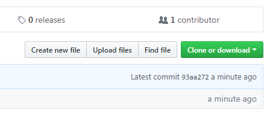

## Steps for using Github for remote version control (continued)

4. Go to GitBash and put the cloned repository under local version control using *cd* to make the cloned repository the local master and use *git init* to initialize a local git repository for version control in the cloned repository

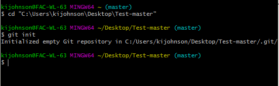

5. Make a copy of your “helloworld.txt” file and *add* it for version control to your cloned repository along with the README.MD file, check the status

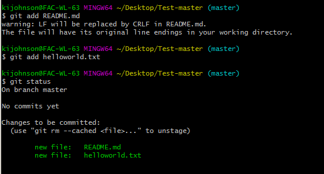

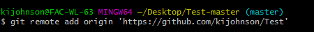

## Steps for using Github for remote version control (continued)

7. Commit your local files (helloworld.txt and README.MD) with a message and add them to your Github repository

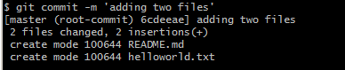

8. *Push* the local files to your remote repository using the *git push -f origin master* command

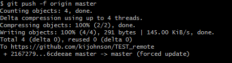

9. Create a new text file called anythingyouwant.txt (calling mine pull.txt) and add the new file to your remote repository by dropping it in and use git bash and the *git pull* command to pull that file to your local repository from your remote repository.

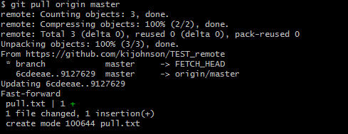

## Forking (last topic)

- Forking is a method where you can fork other Github user repositories to your Github repository and work on it independently
- Fork the class repository to your repository
  - while logged into your Github account go to the class Github website: https://github.com/kijohnson/Advanced-Data-Analysis
  - click on fork in the upper right hand corner

## For help with Git and Unix commands

- Ask Me! (This is *so cutting edge* for public health and social work that Statlab probably won’t be able to help except Alina :))
- Everything you need to know (and way more): https://git-scm.com/book/en/v2
- Unix http://mally.stanford.edu/~sr/computing/basic-unix.html